# A Brief Analysis of Adidas and Nike’s Shoes Sales

AUTHOR: Kien Anh Le

# I. A Brief History Lesson

## Adidas: From Craftsmanship to Global Icon

Founded in **1949** by **Adi Dassler** in Germany, Adidas started with a simple vision: create high-quality athletic shoes to support athletes. Adi designed shoes with innovative spikes for better grip, gaining global recognition when German sprinter **Jesse Owens** wore Dassler-made shoes in the 1936 Olympics, snagging four gold medals. By the 1970s, Adidas had firmly rooted itself in sports, with its **three-stripe** logo becoming iconic. Famous for models like the **Superstar** and **Stan Smith**, Adidas blended function and style, branching into lifestyle and streetwear. Today, Adidas is known for technological footwear advancements, like the **Boost** sole and **Primeknit** fabric, appealing to athletes and sneakerheads alike.

## Nike: Innovation and Endorsement-Driven Dominance

Nike, originally **Blue Ribbon Sports**, was founded in **1964** by **Phil Knight** and **Bill Bowerman**. It initially distributed Japanese shoes before releasing its own design, the **Nike Cortez**, in 1972. Rebranding as Nike, the company adopted the **Swoosh** and launched an aggressive athlete endorsement strategy, famously signing **Michael Jordan** in 1984 and releasing the iconic **Air Jordan** series. This strategy propelled Nike to the forefront of sportswear, with innovations like the **Air Max** line, known for visible air-cushioning, and **Flyknit** technology for lightweight support. Today, Nike’s blend of tech, performance, and exclusive releases fuels its continued popularity and reputation as a global leader in footwear.

Both of these companies have revolutionized footwear. They made basketball shoes a staple of hip culture. They made sliders a cultural icon in all tropical regions. Funnily, they made counterfeit products an entire fashion line.

# II. What’s Popping With Their Shoes?

```python
import pandas as pd
import numpy as np
import matplotlib.pyplot as plt
import seaborn as sns

df = pd.read_csv("Adidas Vs Nike.csv")

df.rename(columns = {"Brand":"Line"},inplace=True)
df["Brand"] = df["Line"].apply(lambda x: "Adidas" if "Adidas" in x else "Nike")
df = df.loc[df['Reviews'] != 0]
```

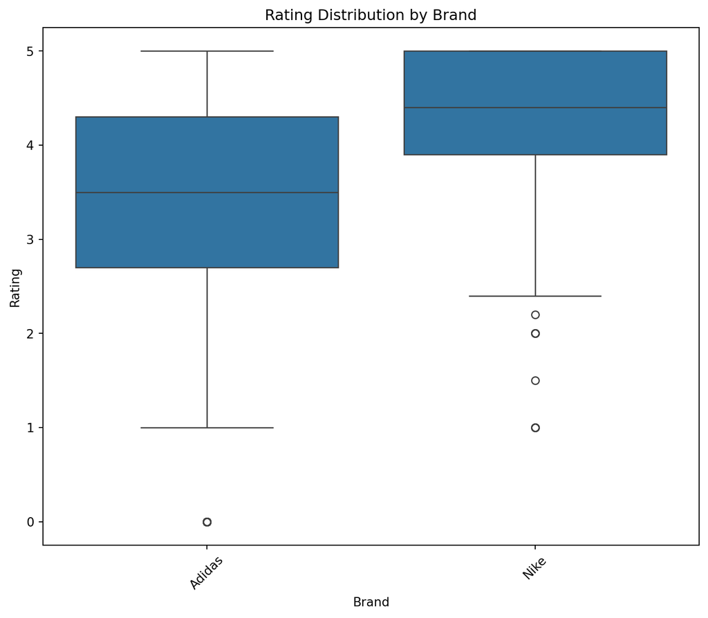

```python
# 1. Brand Distribution and Average Ratings
plt.figure(figsize=(8, 7))
sns.boxplot(x='Brand', y='Rating', data=df)
plt.title('Rating Distribution by Brand')
plt.xticks(rotation=45)
plt.tight_layout()
plt.show()
```

Nike shoes consistently receive higher ratings (out of 5) compared to Adidas, often due to their combination of innovative design and superior comfort. Nike’s pioneering **Air cushioning** technology, seen in models like the **Air Max** and **Air Jordan**, has set a high standard for impact absorption and comfort, which many reviewers praise as ideal for everyday wear and high-performance activities. Additionally, Nike’s **Flyknit** material is lightweight and breathable, making their shoes comfortable over long periods. Another factor is Nike’s strong athlete endorsements and cultural impact, especially with limited releases that drive exclusivity, leading consumers to feel part of a unique community. While Adidas excels with classics like **Boost** and the **Ultraboost** for lifestyle and running, Nike’s continuous innovation and marketing edge often make its products feel fresher and more technically advanced, translating to higher user satisfaction and better ratings overall.

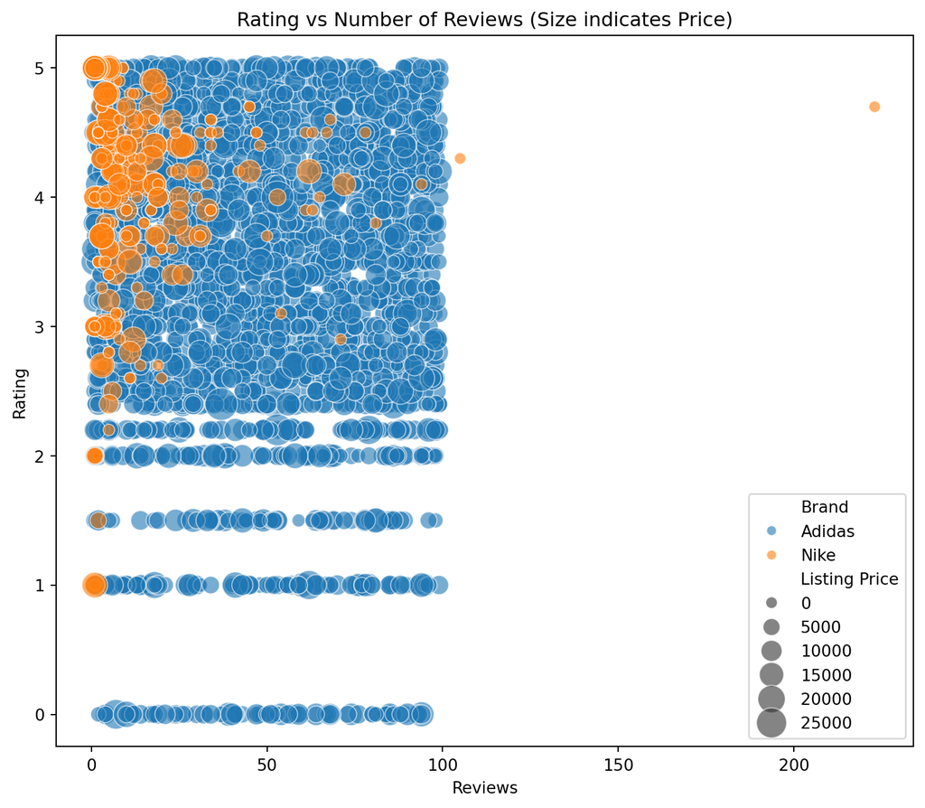

```python
# 2. Reviews vs Rating Analysis with Brand distinction
plt.figure(figsize=(8, 7))
sns.scatterplot(data=df, x='Reviews', y='Rating', hue='Brand', size='Listing Price',sizes=(50, 400), alpha=0.6)
plt.title('Rating vs Number of Reviews (Size indicates Price)')
plt.tight_layout()
plt.show()
```

Both brands have products in the low-rating spectrum (1-2), but Adidas exhibits a noticeably larger cluster in this range. This suggests that more Adidas products are receiving negative feedback compared to Nike. The higher concentration of low ratings for Adidas could stem from quality or performance issues in specific models, or it could indicate that Adidas caters to more budget-friendly segments, where customer expectations are varied.

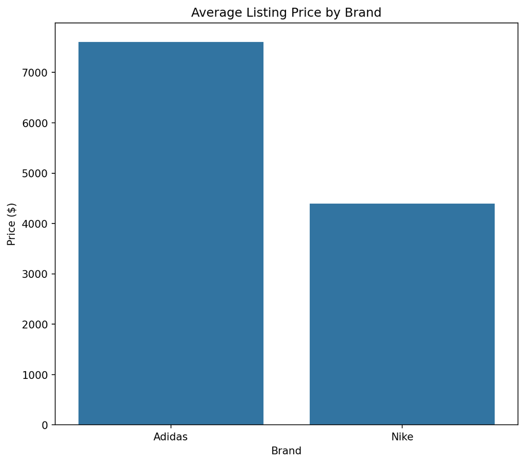

```python
# 3. Average Price Comparison
plt.figure(figsize=(8, 7))
sns.barplot(x='Brand', y='Listing Price', data=df, errorbar=None)
plt.title('Average Listing Price by Brand')
plt.ylabel('Price ($)')
plt.show()
```

Adidas’s average price is visibly higher than Nike’s, reaching approximately **7,000 USD** compared to Nike’s average of about **4,000 USD**. This substantial difference suggests that Adidas may focus more on high-end or premium-priced models, potentially with luxury collaborations, limited editions, or specialized technology that commands a higher price point.

The higher average price for Adidas could also reflect its strategy of positioning itself as a premium brand within certain segments. Higher prices can impact consumer perception, where Adidas is viewed as offering exclusive, high-value footwear that justifies a higher cost. On the other hand, Nike’s lower average price suggests that it targets a broader, potentially more budget-conscious audience. Nike’s pricing strategy may be aimed at maintaining accessibility to a larger market, balancing affordability with innovation.

Adidas’s premium pricing aligns with a luxury or niche market positioning, possibly focusing on unique models and brand collaborations that can command higher prices. Meanwhile, Nike’s relatively lower pricing indicates a strategic emphasis on volume, appealing to a diverse range of consumers while still offering high-performance products.